[figure not shown]

# مصورسازی داده (Data Visualization)

*مدت زمان لازم برای مطالعه: ۴۰ دقیقه*

## مقدمه

مصورسازی داده بخش مهمی از تجزیه و تحلیل داده است. مصورسازی به ما کمک می کند تا روابط بین متغیرها را بشناسیم و همچنین تشخیص دهیم کدام متغیرها مهم هستند یا می‌توانند در مقدار متغیر دیگری تاثیر بگذارند.

کتابخانه `matplotlib` یکی از کتابخانه‌های ترسیم در زبان برنامه‌سازی پایتون است. مجموعه `matplotlib.pyplot` شامل توابعی است که به ما کمک می‌کنند با مشخص کردن بخش های اساسی یک نمودار، آن را رسم کنیم.

در این آموزش ما از مجموعه داده [mpg](http://fueleconomy.gov) استفاده می‌کنیم. این مجموعه شامل اطلاعات جمع‌آوری شده از ۲۳۴ خودرو است. ستون‌های این مجموعه داده عبارت‌اند از:

> - model: نام مدل
> - displ: اندازه موتور
> - year: سال ساخت
> - cyl: تعداد سیلندر
> - hwy: مسافت طی‌شده با یک گالن سوخت در بزرگراه
> - cty: مسافت طی‌شده با یک گان سوخت در شهر
> - fl: نوع سوخت
> - class: کلاس ماشین

## نصب کتابخانه matplotlib

برای نصب یا بروزرسانی کتاب‌خانه `matplotlib` می‌توانید دستور زیر را در محیط `command line` وارد کنید:

```
pip3 install matplotlib
```

پس از اتمام فرایند نصب ، برای استفاده از آن لازم است کتاب‌خانه را به کد اضافه کنید؛ توجه داشته باشید برای سهولت استفاده، مخفف `plt` را برای فراخوانی `matplotlib.pyplot` تعریف می‌کنیم.

```python
import numpy as np
import pandas as pd
import matplotlib.pyplot as plt
```

## تابع plot

برای رسم هر تابع دلخواه می‌توان از تابع `plot` استفاده کرد. این تابع با ورودی گرفتن مجموعه مقادیر `x` و `y` تابعی را با استفاده از آن‌ها رسم می‌کند. در مثال زیر تابع `sin` در پنچاه نقطه در بازه‌ی $[-\pi, \; \pi]$ رسم شده است.

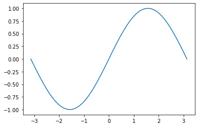

```python
pi = np.pi
x = np.linspace(start=-pi, stop=pi, num=50)
y = np.sin(x)
plt.plot(x, y)
plt.show()
```

برای نمایش نمودار از تابع `show` استفاده می‌کنیم.

در نمودار زیر با تغییر پارامتر‌های `markersize`، `marker`، ‍`linewidth`، `linestyle` و `color` صورت‌های مختلف نمودار قبلی را رسم کنید.

پارامتر‌های `markersize` و `linewidth` عدد طبیعی‌اند. همچنین در جدول زیر برخی از مقادیر ممکن برای پارامتر‌های `marker` و `linestyle` آمده است.

| پارامتر | مقدار |
| --- | --- |
| `marker` | '.' '*' '+' |
| `linestyle` | '-' '--' '-.' ':' |

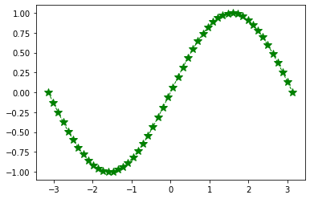

```python
plt.plot(x, y, color='green', linewidth=1, linestyle='--', marker='*', markersize=10)
plt.show()
```

همان‌طور که احتمالا متوجه شدید با تعیین پارامتر `marker` می‌توان مکان دقیق داده‌ها را در نمودار نشان داد.

## نمودار پراکندگی (scatter plot)

در نمودار پراکندگی می‌توان داده‌ها را با استفاده از دو یا سه ویژگی عددی در دستگاه مختصات رسم کنیم. برای این کار از تابع `scatter` استفاده می‌کنیم.  
ابتدا مجموعه داده mpg را می‌خوانیم.

```python
mpg_csv_url = "https://drive.google.com/uc?export=download&id=1FEFRjJoc5meIdrzGl8yG3U5Jqw-JY0j7"
```

```python
df = pd.read_csv(mpg_csv_url)
df.head()
```

|  | Unnamed: 0 | manufacturer | model | displ | year | cyl | trans | drv | cty | hwy | fl | class |
| --- | --- | --- | --- | --- | --- | --- | --- | --- | --- | --- | --- | --- |
| 0 | 1 | audi | a4 | 1.8 | 1999 | 4 | auto(l5) | f | 18 | 29 | p | compact |
| 1 | 2 | audi | a4 | 1.8 | 1999 | 4 | manual(m5) | f | 21 | 29 | p | compact |
| 2 | 3 | audi | a4 | 2.0 | 2008 | 4 | manual(m6) | f | 20 | 31 | p | compact |
| 3 | 4 | audi | a4 | 2.0 | 2008 | 4 | auto(av) | f | 21 | 30 | p | compact |
| 4 | 5 | audi | a4 | 2.8 | 1999 | 6 | auto(l5) | f | 16 | 26 | p | compact |

به عنوان مثال نمودار پراکندگی مقدار مسافت طی‌شده با یک گالن سوخت (hwy) نسبت به اندازه موتور خودرو (displ) را رسم می‌کنیم.

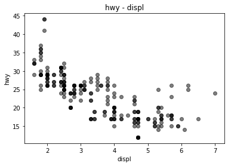

```python
plt.scatter(x=df['displ'], y=df['hwy'], c='black', alpha=0.5)
plt.title('hwy - displ')
plt.xlabel('displ')
plt.ylabel('hwy')
plt.show()
```

برای استفاده از تابع `scatter` لازم است مقادیر هر بعد را مشخص نماییم. از طرفی با استفاده از پارامتر `alpha` میزان شفافیت هر نشان را مشخص می‌کنیم. بنابراین در مکان‌هایی که نشان پررنگ‌تر است، در واقع داده‌های بیشتری رو هم قرار گرفته‌اند. برای تعیین عنوان نمودار از تابع `title` و برای نام‌گذاری محور‌ها از توابع `xlabel` و `ylabel` استفاده می‌کنیم.

حال می‌خواهیم با استفاده از ویژگی تعداد سیلندر داده‌ها را رنگ کنیم.

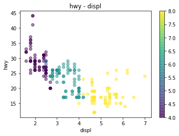

```python
plt.scatter(x=df['displ'], y=df['hwy'], c=df['cyl'],alpha=0.5)
plt.title('hwy - displ')
plt.xlabel('displ')
plt.ylabel('hwy')
plt.colorbar()
plt.show()
```

به کمک تابع colorbar می‌توانیم طیف رنگ را نمایش دهیم. همان طور که انتظار داشتیم، خودرو‌های با تعداد سیلندر بیشتر مصرف سوخت بیشتری دارند.

## نمودار سه‌بعدی

در این بخش مجموعه دادگان mpg را با استفاده از سه ویژگی عددی در دستگاه مختصات رسم می‌کنیم. به این منظور از ابزار `mplot3d` در کنار `matplotlib` استفاده می‌کنیم.

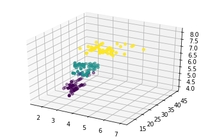

```python
from mpl_toolkits import mplot3d
fig = plt.figure()
ax = plt.axes(projection='3d')
ax.scatter3D(df['displ'], df['hwy'], df['cyl'], c=df['cyl'])
plt.show()
```

همان‌طور که مشاهده‌ می‌شود با اضافه کردن ویژگی تعداد سیلندر داده‌ها به خوبی خوشه‌بندی شده‌اند.

## نمودار میله‌ای (bar plot)

با استفاده از این نمودار می‌توان کمیت عددی مربوط به مقادیر متفاوت یک کمیت دسته‌ای را نمایش داد و با هم مقایسه کرد.

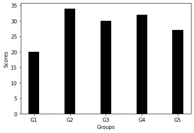

```python
groups = ['G1', 'G2', 'G3', 'G4', 'G5']
scores = [20, 34, 30, 32, 27]
bar_width = 0.3
plt.bar(groups, scores, width=bar_width, color='black')
plt.xlabel('Groups')
plt.ylabel('Scores')
plt.show()
```

در نمودار میله‌ای بعد میانگین hwy و cty را برای کلاس‌های متفاوت خودرو‌ها به صورت همزمان نشان می‌دهیم.

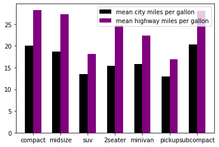

```python
classes = df['class'].unique()
barwidth = 0.3
cty_mean = []
hwy_mean = []
for x in classes:
    cty_mean.append(df[df['class'] == x]['cty'].mean())
    hwy_mean.append(df[df['class'] == x]['hwy'].mean())

index = pd.factorize(classes)[0] + 1
plt.bar(index, cty_mean, barwidth, color='black', label='mean city miles per gallon')
plt.bar(index + barwidth, hwy_mean, barwidth, color='purple', label='mean highway miles per gallon')
plt.xticks(index + barwidth / 2, classes)
plt.legend()
plt.show()
```

تابع `xticks` با گرفتن مکان دسته‌ها و نامشان، آن‌ها را روی محور x نمایش می دهد. هنگامی که چند نمودار را در یک شکل رسم می‌کنیم، می‌‌توان با تعیین پارامتر `label` برای نمودار‌ها و فراخوانی تابع `legend`، برچسب تعیین شده برای هر نمودار را در شکل نشان دهیم. دقت کنید در این شکل ما دو نمودار را به صورت همزمان به تصویر کشیدیم. در حالت کلی می‌توانیم تعداد دلخواهی نمودار با نوع مطلوب در یک شکل رسم کنیم.

## نمودار جعبه‌ای (box plot)

در نمودار جعبه‌ای خلاصه‌ای از دادگان شامل کمینه، چارک اول، میانه، چارک سوم و بیشینه نمایش داده می‌شود.

[figure not shown]

نمودار جعبه‌ای

در کد زیر از توابع تعریف شده روی dataframe برای کشیدن نمودار استفاده شده است. برای مطالعه‌ی بیشتر می‌توانید به این [لینک](https://pandas.pydata.org/pandas-docs/stable/reference/frame.html#plotting) مراجعه کنید.

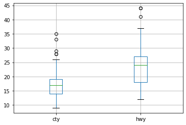

```python
df.boxplot(column=['cty', 'hwy'])
plt.show()
```

در نمودار زیر داده‌ها ابتدا بر حسب ویژگی class گروه‌بندی شده‌اند، سپس نمودار جعبه‌ای برای هر دسته رسم شده است.

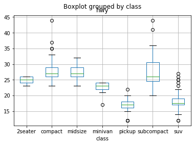

```python
df.boxplot(column=['hwy'], by='class')
plt.show()
```

## نمودار کانتوری (contour plot)

برای نمایش نمودار سه‌بعدی در دو بعد می‌توان از نمودار کانتوری استفاده کرد.

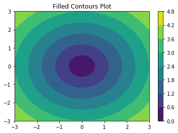

```python
xlist = np.linspace(-3.0, 3.0, 100)
ylist = np.linspace(-3.0, 3.0, 100)
X, Y = np.meshgrid(xlist, ylist)
Z = np.sqrt(X**2 + Y**2)
plt.contourf(X, Y, Z)
plt.colorbar()
plt.title('Filled Contours Plot')
plt.show()
```

## آشنایی با کتابخانه seaborn

یکی دیگر از کتابخانه‌های ترسیم در زبان پایتون `seaborn`است که بر پایه `matplotlib` نوشته شده‌است. برای نصب یا بروزرسانی کتاب‌خانه `seaborn` می‌توانید دستور زیر را در محیط `command line` وارد کنید:

```
pip3 install seaborn
```

پس از اتمام فرایند نصب ، برای استفاده از `seaborn` لازم است کتاب‌خانه را به کد اضافه کنید؛ برای سهولت استفاده، مخفف `sns` را برای فراخوانی آن تعریف می‌کنیم.

```python
import seaborn as sns

sns.set_style('darkgrid')
```

از تابع `set_style` برای تغییر پیش‌فرض زمینه نمودارها استفاده می‌کنیم.  
در ادامه برای آشنایی بیشتر با کتابخانه `seaborn` روش رسم چند نوع نمودار را با استفاده از آن، بررسی می‌کنیم.

## نمودار هیستوگرام (Histogram)

هیستوگرام نمایشی از توزیع داده‌های کمی پیوسته است که می‌تواند تخمینی از توزیع احتمال یک متغیر باشد.  
به عنوان مثال برای مجموعه داده‌ mpg نمودار histogram ویژگی hwy نمونه‌هایی که چهار سیلندر دارند به صورت زیر است. این نمودار تخمینی از توزیع احتمال شرطی hwy به شرط cyl = 4 است.

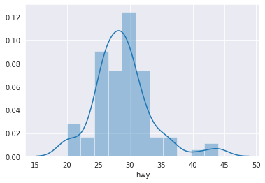

```python
df = pd.read_csv(mpg_csv_url)
sns.distplot(df[df['cyl'] == 4].hwy)
plt.show()
```

## نمودار پراکندگی (scatter plot)

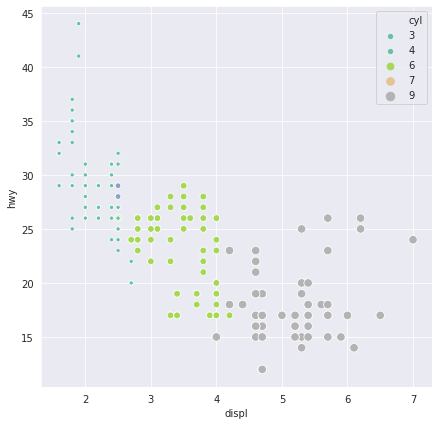

```python
plt.figure(figsize=(7, 7))
ax = sns.scatterplot(data=df, x='displ', y='hwy', hue='cyl', size='cyl', palette='Set2')
plt.show()
```

همان طور که قبلا مشاهده کردیم، خودرو‌های با تعداد سیلندر بیشتر مصرف سوخت بیشتری دارند.  
از تابع `figure` برای تغییر اندازه‌ی نمودار استفاده می‌کنیم.  
پارامتر `data` مجموعه داده مورد نظر و پارامتر‌های `x` و `y` نام ستون‌های دو ویژگی عددی از داده هستند.همچنین پارامتر `hue` برای تعیین رنگ هر نقطه و پارامتر `size` برای تعیین اندازه با توجه به یکی از ویژگی‌های آن است.  
پارامتر `palette` برای تعیین رنگ‌های مورد استفاده در نمودار است که مقدار آن نام یک پالت آماده کتابخانه، دیکشنری یا لیستی از رنگ‌ها می‌تواند باشد . به عنوان مثال مقدار این پارامتر می‌تواند GnBu_d, Set1, Set3, magma, spring, cubehelix و ... باشد.

## نمودار میله‌ای (bar plot)

اکنون می‌خواهیم میانگین cty را برای انواع کلاس‌های ماشین در یک نمودار میله‌ای مقایسه کنیم.

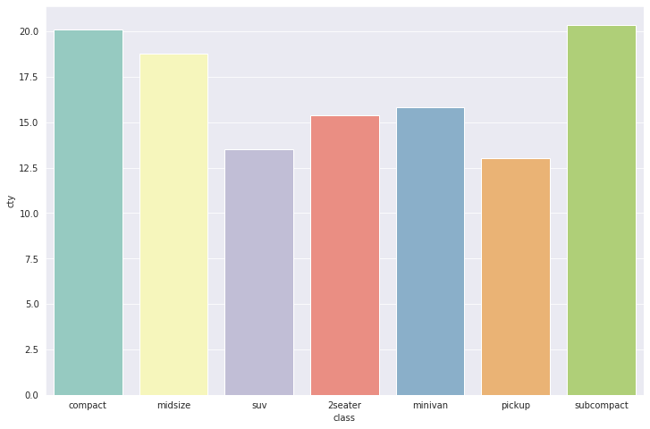

```python
plt.figure(figsize=(12, 8))
ax = sns.barplot(data=df, x='class', y='cty', palette='Set3', ci=None, estimator=np.mean)
plt.show()
```

نمودار میله‌ای برای هر گروه مشخص‌شده در `x` یک مقدار جدید محاسبه می‌کند که تابع متناظر با آن را در پارامتر `estimator` ورودی می‌گیرد. به عنوان مثال این تابع می‌تواند تعداد نمونه‌های هر گروه ( `len` ) یا آماره‌ای از آن مانند میانگین ( `np.mean` ) میانه ( `p.median` ) و غیره را محاسبه کند.  
بازه اطمینان برای تخمین آماره‌ای از داده، بازه‌ای است که با احتمال مشخص (مانند $1-\alpha$) شامل مقدار واقعی آن آماره است. با تنظیم پارامتر `ci` این تابع می‌تواند یک بازه اطمینان برای `estimator` محاسبه کرده و نمایش دهد. به این ترتیب `ci` می‌تواند یک عدد اعشاری در بازه $[0, 100]$ به معنی درصد اطمینان باشد. این پارامتر دو مقدار مجاز دیگر نیز دارد که `ci='sd'` انحراف معیار را نمایش داده و `ci=None` مانع از نمایش بازه اطمینان می‌شود.  
این تابع می‌تواند هر ستون `x` را بر اساس ویژگی دیگری group by کند. برای این کار کافی است نام ستون مربوطه را در پارامتری با نام `hue` مشخص کنید.

## نمودار جعبه‌ای (box plot)

بار دیگر نمودار جعبه‌ای hwy را با استفاده از کتابخانه `seaborn` برای کلاس‌های مختلف ماشین رسم می‌کنیم.

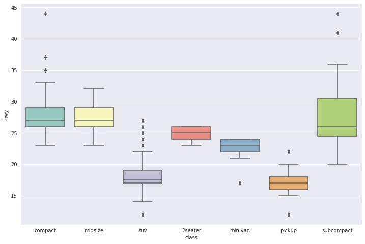

```python
plt.figure(figsize=(12, 8))
ax = sns.boxplot(data=df, x='class', y='hwy', palette='Set3', showfliers=True)
plt.show()
```

با استفاده از `showfliers=False` می‌توان مانع از نمایش داده‌های پرت شد.

## نمودار نقشه گرمایی (heatmap)

برای بررسی میزان همبستگی ویژگی‌های عددی مجموعه داده mpg می‌توانیم ماتریس همبستگی آن‌ها را با استفاده از نمودار heatmap رسم کنیم.

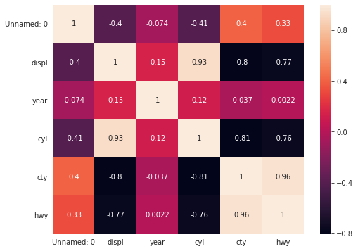

```python
plt.figure(figsize=(8, 6))
ax = sns.heatmap(df.corr(),annot=True)
plt.show()
```

به عنوان مثال، از بررسی نمودار بالا می‌توان نتیجه گرفت ویژگی‌های cty با hwy رابطه مستقیم و با displ تقریبا رابطه عکس دارد. اما سال ساخت با هیچ کدام از ویژگی‌ها همبستگی ندارد.

## نکات تکمیلی

برای مطالعه ببشتر می‌توانید به لینک‌های زیر مراجعه کنید.

> - [Matplotlib](https://matplotlib.org/tutorials/introductory/pyplot.html#sphx-glr-tutorials-introductory-pyplotpy)
> - [Seaborn](http://seaborn.pydata.org/api.html)
> - [DataFrame Plotting](https://pandas.pydata.org/pandas-docs/stable/reference/frame.html#plotting)